# PS 6

Ilayda Koca

2022-10-17

## Getting Set Up

If you haven’t already, create a folder for this course, and then a subfolder within for the second lecture `Topic8_Regression`, and two additional subfolders within `code` and `data`.

Open `RStudio` and create a new RMarkDown file (`.Rmd`) by going to `File -> New File -> R Markdown...`. Change the title to `"DS1000: Problem Set 6"` and the author to your full name. Save this file as `[LAST NAME]_ps6.Rmd` to your `code` folder.

If you haven’t already, download the `mv.Rds` file from the course [github page](https://github.com/jbisbee1/DS1000-F2022/blob/master/Lectures/Topic8_Regression/data/mv.Rds) and save it to your `data` folder.

The contents of this problem set can be found in the following resources:

- [Topic 6](https://github.com/jbisbee1/DS1000-F2022/tree/master/Lectures/Topic6_UnivariateVisualization) parts 1 & 2 (univariate visualization)
- [Topic 7](https://github.com/jbisbee1/DS1000-F2022/tree/master/Lectures/Topic7_ConditionalVariation) parts 1 & 2 (conditional analysis)
- [Topic 8](https://github.com/jbisbee1/DS1000-F2022/tree/master/Lectures/Topic8_Regression) parts 1 & 2 (regression, RMSE, and cross validation)

Require `tidyverse` and load the `mv.Rds` data to `mv`.

```r
require(tidyverse)
mv <- readRDS('../data/mv.Rds')
```

**NOTE**: Starting with this problem set, we are moving to a system with fewer questions that are each more involved. For EACH of the questions below, you are expected to:

1. Perform uni-variate analysis on each of the two variables separately (determine their class, identifying missing-nes, and plot with the appropriate figure).
2. Plot the conditional relationship between the two variables using the appropriate figure. Transform the variables if needed by logging highly skewed data.
3. Estimate the linear regression model.
4. Evaluate model fit with 1) visual analysis of the residuals and 2) cross validation.

## Question 1 [10 points]

- **Research Question:** Are longer movies more expensive to make?
- **Theory:** Longer running movies take more time to make. Time is money.
- **Hypothesis:** The longer the movie, the more expensive it is.
- *Hints:* You are looking at the conditional relationship between `budget` and `runtime`.

```r
#look at the data to find missing data.
mv_sum <- mv %>%
  select(budget, runtime) %>%
  summary()

mv_sum
```

```
##      budget             runtime
##  Min.   :     5172   Min.   : 55.0
##  1st Qu.: 16865322   1st Qu.: 95.0
##  Median : 37212044   Median :104.0
##  Mean   : 57420173   Mean   :107.3
##  3rd Qu.: 77844746   3rd Qu.:116.0
##  Max.   :387367903   Max.   :366.0
##  NA's   :4482        NA's   :4
```

```r
#1. Perform uni-variate analysis on each of the two variables separately (determine their class, identifying missing-nes, and plot with the appropriate figure).
g0 <- mv %>%
  select(budget,runtime) %>%
  glimpse()
```

```
## Rows: 7,673
## Columns: 2
## $ budget  <dbl> NA, NA, NA, NA, NA, NA, NA, NA, NA, NA, NA, NA, NA, NA, NA, NA…
## $ runtime <dbl> 146, 104, 124, 88, 98, 95, 133, 129, 127, 100, 116, 109, 114, …
```

```r
g0
```

```
## # A tibble: 7,673 × 2
##    budget runtime
##     <dbl>   <dbl>
##  1     NA     146
##  2     NA     104
##  3     NA     124
##  4     NA      88
##  5     NA      98
##  6     NA      95
##  7     NA     133
##  8     NA     129
##  9     NA     127
## 10     NA     100
## # … with 7,663 more rows
```

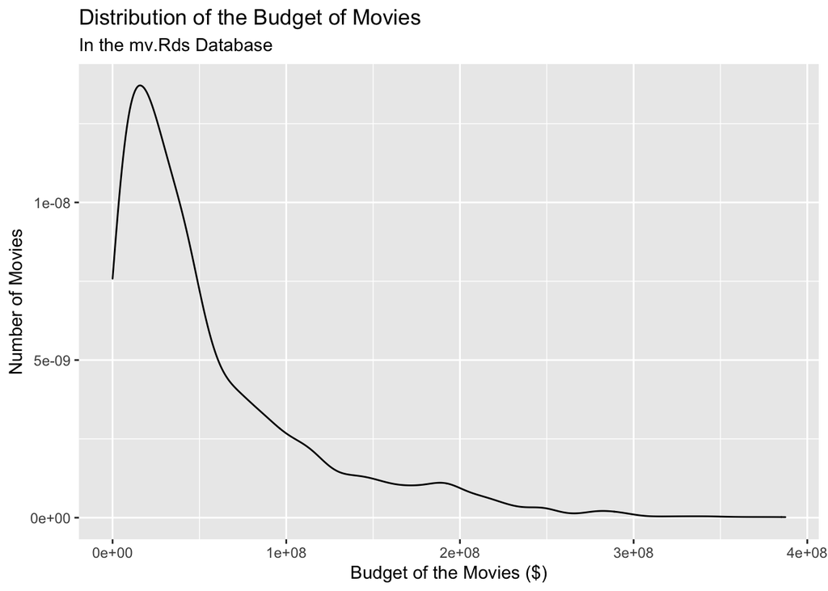

```r
g1 <- mv %>%
  ggplot(aes(x = budget, na.rm=T)) +
  geom_density() +
  labs(title = "Distribution of the Budget of Movies",
       subtitle = "In the mv.Rds Database",
       y = "Number of Movies",
       x = "Budget of the Movies ($)")

g1
```

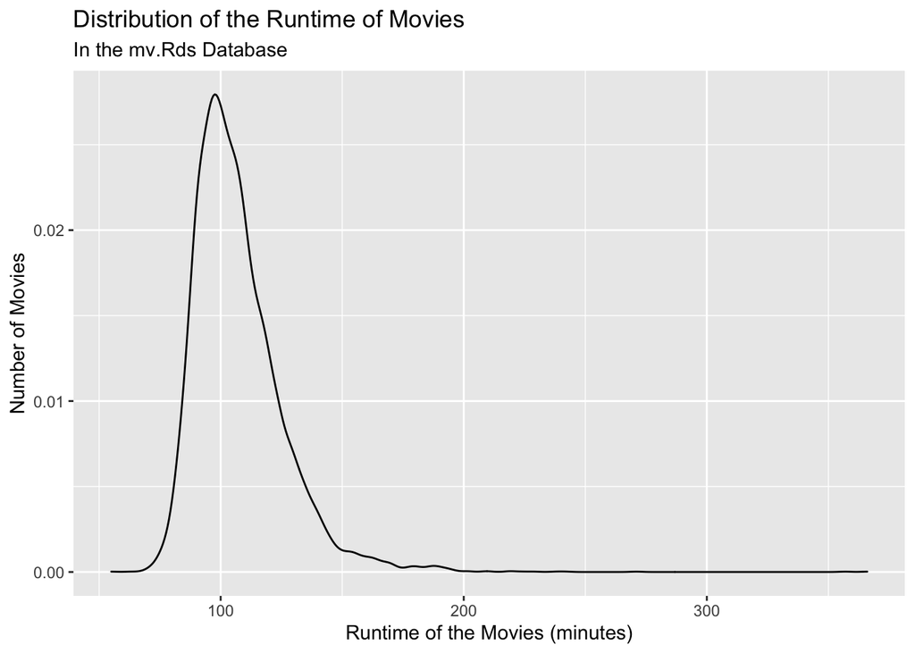

```r
g2 <- mv %>%
  ggplot(aes(x = runtime, na.rm=T)) +
  geom_density() +
  labs(title = "Distribution of the Runtime of Movies",
       subtitle = "In the mv.Rds Database",
       y = "Number of Movies",
       x = "Runtime of the Movies (minutes)")

g2
```

```r
# 2. Plot the conditional relationship between the two variables using the appropriate figure. Transform the variables if needed by logging highly skewed data.
g3 <- mv %>%
  select(budget,runtime) %>%
  filter(complete.cases(.)) %>%
  glimpse()
```

```
## Rows: 3,189
## Columns: 2
## $ budget  <dbl> 93289619, 10883789, 160147179, 6996721, 13993443, 139934429, 2…
## $ runtime <dbl> 122, 101, 155, 102, 113, 143, 88, 130, 100, 104, 130, 165, 131…
```

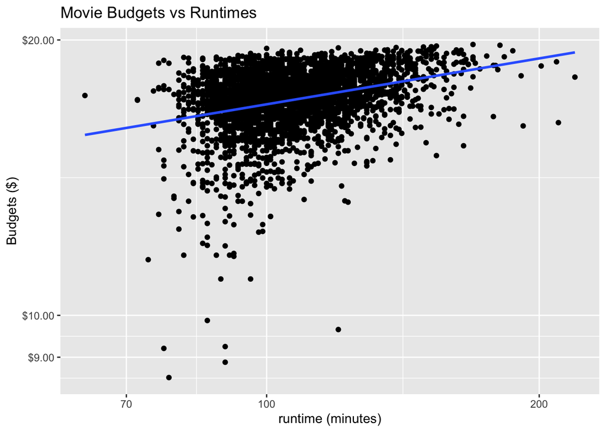

```r
g5 <- g3 %>%
  ggplot() +
  geom_density(aes(x = log(budget)), color = 'forestgreen',lwd=2) +
  geom_density(aes(x = runtime), color = 'tomato',lwd=2)

g6 <- g3 %>%
  ggplot(aes(x = runtime, y = log(budget))) +
  geom_point() +
  scale_y_log10(labels = scales::dollar) +
  scale_x_log10() +
  geom_smooth(method = 'lm', se = F) +
  labs(title = "Movie Budgets vs Runtimes",
       y = "Budgets ($)",
       x = "runtime (minutes)")

g6
```

```r
# 3. Estimate the linear regression model.
#clear the data set of NA values
q1 <- mv %>%
  select(runtime,budget) %>%
  drop_na(runtime,budget)

m1 <- lm(log(budget) ~ runtime, q1)

q1 <- q1 %>%
  mutate(predicted_budget = predict(m1)) %>%
  mutate(errors = log(budget) - predicted_budget)

#RMSE
# E: errors
e1 <- log(q1$budget) - q1$predicted_budget
# SE: squared
se1 <- e1^2
# MSE: mean
mse1 <- mean(se1, na.rm = T)
# RMSE: root
(rmse1 <- sqrt(mse1))
```

```
## [1] 1.24021
```

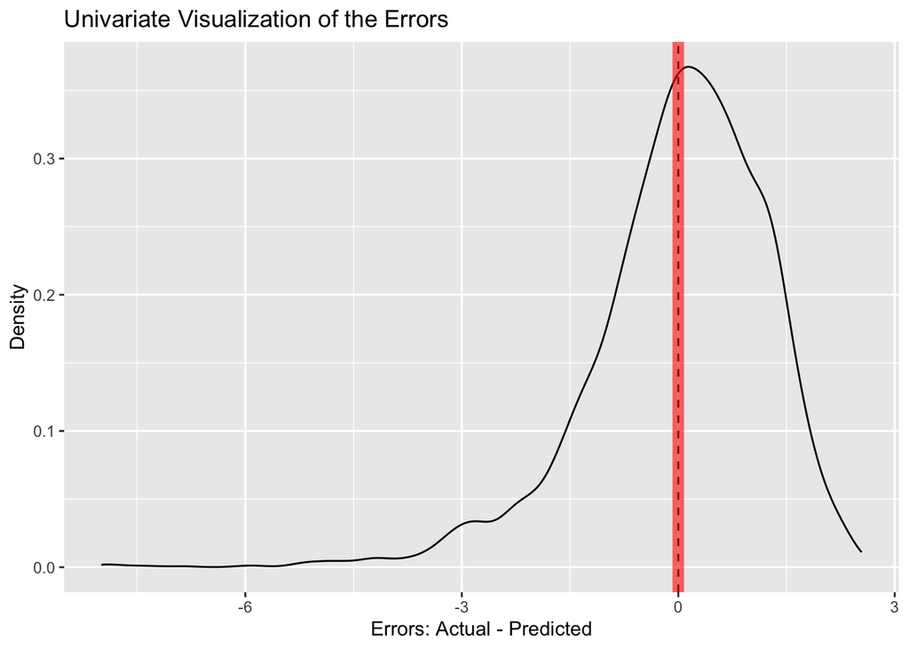

```r
# 4. Evaluate model fit with 1) visual analysis of the residuals
mvAnalysis <- mv %>%
  select(runtime, budget) %>%
  drop_na()

m3 <- lm(log(budget) ~ runtime,mvAnalysis)

pred_vals <- predict(m3)

errors <- resid(m3)

mvAnalysis$pred_vals <- pred_vals

mvAnalysis$errors <- log(mvAnalysis$budget) - mvAnalysis$pred_vals

mvAnalysis <- mvAnalysis %>%
  mutate(errors = log(budget) - pred_vals)

# Uni-variate visualization of the errors
mvAnalysis %>%
  ggplot(aes(x = errors)) +
  geom_density() +
  geom_vline(xintercept = 0,linetype = 'dashed') +
  geom_vline(xintercept = mean(mvAnalysis$errors),
             color = 'red',size = 3,alpha = .6) +
  labs(title = "Univariate Visualization of the Errors",
       y = "Density",
       x = "Errors: Actual - Predicted")
```